# Macroevolutionary analysis with microevolutionary priors

This tutorial will guide you through the use of soon to be released bayou v2.0. The goal of bayou is to fit Ornstein-Uhlenbeck models to phylogenies without a priori hypotheses about regime placement. bayou v2.0 adds flexibility for implementation of customized models. First, let’s install and load the R packages we will use for this exercise:

```r
devtools::install_github("uyedaj/bayou", ref="dev")
install.packages("treeplyr")
```

```r
library(bayou)
library(treeplyr)
```

# Preparing data for analysis with the R package treeplyr.

We will use data from the Species 360 database of normal animal reference ranges for a variety of traits (formerly known as the International Species Information System = ISIS). The data file has been slightly modified here, but the original data file is available at: http://www2.isis.org/support/MEDARKS/Pages/Reference%20Ranges.aspx

```r
sp360 <- readRDS("../data/species360.rds")
tbl_df(sp360)
```

```
## # A tibble: 2,299 x 259
##                    SPECIES ALANINEAMINOTRANSFERASE ALBUMIN_COLORIMETRY
##                      <chr>                   <dbl>               <dbl>
## 1           Aburria_pipile                      13                 1.5
## 2         Acanthis_flammea                     NaN                 NaN
## 3     Acanthochelys_spixii                      10                 NaN
## 4  Acanthophis_antarcticus                     NaN                 NaN
## 5   Acanthosaura_crucigera                     NaN                 1.2
## 6       Accipiter_cooperii                      52                 1.4
## 7          Aceros_cassidix                      40                 1.8
## 8        Aceros_corrugatus                      27                 1.7
## 9     Aceros_leucocephalus                     NaN                 1.9
## 10        Acinonyx_jubatus                     103                 3.5
## # ... with 2,289 more rows, and 256 more variables:
## #   ALBUMIN_ELECTROPHORESIS <dbl>, ALKALINEPHOSPHATASE <dbl>,
## #   ALPHA1GLOBULIN_ELECTROPHORESIS <dbl>,
## #   ALPHA2GLOBULIN_ELECTROPHORESIS <dbl>,
## #   ALPHAGLOBULIN_ELECTROPHORESIS <dbl>, AMYLASE <dbl>,
## #   ASPARTATEAMINOTRANSFERASE <dbl>, AZUROPHILS <dbl>, BASOPHILS <dbl>,
## #   BETAGLOBULIN_ELECTROPHORESIS <dbl>, BICARBONATE <dbl>,
## #   BLOODUREANITROGEN <dbl>, BodyTemperature <dbl>, CALCIUM <dbl>,
## #   CARBONDIOXIDE <dbl>, CHLORIDE <dbl>, CHOLESTEROL <dbl>,
## #   CORTISOL <dbl>, CREATINEPHOSPHOKINASE <dbl>, CREATININE <dbl>,
## #   DIRECTBILIRUBIN <dbl>, EOSINOPHILS <dbl>,
## #   ERYTHROCYTESEDIMENTATIONRATE <dbl>, ESTROGEN <dbl>, FIBRINOGEN <dbl>,
## #   FREETRIIODOTHYRONINE <dbl>, GAMMAGLOBULIN_ELECTROPHORESIS <dbl>,
## #   GAMMAGLUTAMYLTRANSFERASE <dbl>, GLOBULIN_COLORIMETRY <dbl>,
## #   GLUCOSE <dbl>, HEMATOCRIT <dbl>, HEMOGLOBIN <dbl>, HETEROPHILS <dbl>,
## #   HIGHDENSITYLIPOPROTEINCHOLESTEROL <dbl>, INDIRECTBILIRUBIN <dbl>,
## #   IRON <dbl>, LACTATEDEHYDROGENASE <dbl>, LEAD <dbl>, LIPASE <dbl>,
## #   LOWDENSITYLIPOPROTEINCHOLESTEROL <dbl>, LYMPHOCYTES <dbl>,
## #   MAGNESIUM <dbl>, MCH <dbl>, MCHC <dbl>, MCV <dbl>, MONOCYTES <dbl>,
## #   NEUTROPHILICBANDS <dbl>, NUCLEATEDREDBLOODCELLS <dbl>,
## #   OSMOLARITY <dbl>, PHOSPHORUS <dbl>, PLATELETCOUNT <dbl>,
## #   POTASSIUM <dbl>, PROGESTERONE <dbl>, REDBLOODCELLCOUNT <dbl>,
## #   RETICULOCYTES <dbl>, SEGMENTEDNEUTROPHILS <dbl>, SODIUM <dbl>,
## #   TESTOSTERONE <dbl>, TOCOPHEROL <dbl>, TOCOPHEROL,ALPHA <dbl>,
## #   TOCOPHEROL,GAMMA <dbl>, TOTALBILIRUBIN <dbl>,
## #   TOTALPROTEIN_COLORIMETRY <dbl>, TOTALPROTEIN_REFRACTOMETER <dbl>,
## #   TOTALTHYROXINE_RIA <dbl>, TOTALTRIIODOTHYRONINE_RIA <dbl>,
## #   TRIGLYCERIDE <dbl>, TRIIODOTHYRONINEUPTAKE <dbl>, URICACID <dbl>,
## #   Weight_01daysage <dbl>, Weight_0.91.1monthsage <dbl>,
## #   Weight_0.91.1yearsage <dbl>, Weight_1.41.6yearsage <dbl>,
## #   Weight_14.515.5yearsage <dbl>, Weight_1.82.2monthsage <dbl>,
## #   Weight_1.82.2yearsage <dbl>, Weight_19.021.0yearsage <dbl>,
## #   Weight_2.73.3monthsage <dbl>, Weight_2.73.3yearsage <dbl>,
## #   Weight_4.55.5yearsage <dbl>, Weight_5.46.6monthsage <dbl>,
## #   Weight_68daysage <dbl>, Weight_9.510.5yearsage <dbl>,
## #   WHITEBLOODCELLCOUNT <dbl>, ALANINEAMINOTRANSFERASE.SD <dbl>,
## #   ALBUMIN_COLORIMETRY.SD <dbl>, ALBUMIN_ELECTROPHORESIS.SD <dbl>,
## #   ALKALINEPHOSPHATASE.SD <dbl>, ALPHA1GLOBULIN_ELECTROPHORESIS.SD <dbl>,
## #   ALPHA2GLOBULIN_ELECTROPHORESIS.SD <dbl>,
## #   ALPHAGLOBULIN_ELECTROPHORESIS.SD <dbl>, AMYLASE.SD <dbl>,
## #   ASPARTATEAMINOTRANSFERASE.SD <dbl>, AZUROPHILS.SD <dbl>,
## #   BASOPHILS.SD <dbl>, BETAGLOBULIN_ELECTROPHORESIS.SD <dbl>,
## #   BICARBONATE.SD <dbl>, BLOODUREANITROGEN.SD <dbl>,
## #   BodyTemperature.SD <dbl>, CALCIUM.SD <dbl>, ...
```

The tree file we are using is a mashup of several trees spliced together that includes 29,301 species of vertebrate. First we’re going to make sure we resolve polytomies and set zero length branches to some small value.

```r
tree <- read.tree("../data/tetrapods.tre")
tree <- multi2di(tree, random=FALSE)
tree$edge.length[tree$edge.length==0] <- .Machine$double.eps
```

Matching the tree to the data is easy and fast in treeplyr, simply use the command make.treedata(). The resulting list includes a pruned tree ‘phy’ and a pruned data table in the same order as the tree ‘dat’:

```r
td <- make.treedata(tree, sp360)
```

Let’s choose a trait to study. In this case, let’s use Weight from 1.8-2.2 years old (this isn’t the best dataset for body size, but we’ll use it for now).

```r
tdW <- filter(td, !is.na(Weight_1.82.2yearsage) & Weight_1.82.2yearsage > 0) %>%
  mutate(., lnMass = log(Weight_1.82.2yearsage), lnMass.SD = Weight_1.82.2yearsage.SD/Weight_1.82.2yearsage,N = Weight_1.82.2yearsage.N) %>%
  dplyr::select(., lnMass, lnMass.SD, N)
```

Visualize the trait on the tree (always do this!!)

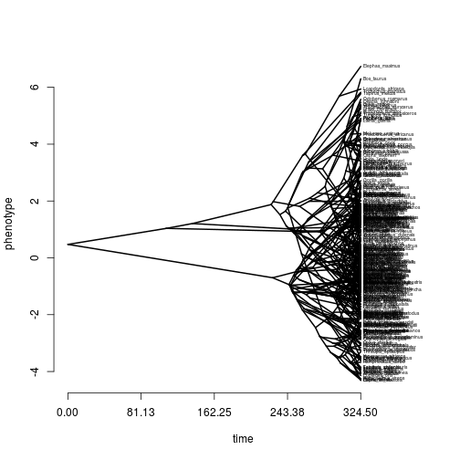

```r
phenogram(tdW$phy, tdW[['lnMass']], spread.labels=FALSE, fsize=0.4)
```

Run a bayou analysis by first setting up a prior distribution for parameters. Let’s split up the data frame now that everything is order and make our prior distribution.

```r
tree <- tdW$phy
dat <- tdW[[1]]
ME <- tdW[['lnMass.SD']]/sqrt(tdW[['N']])

priorOU <- make.prior(tree,
                      dists=list(dalpha="dhalfcauchy", dsig2="dhalfcauchy",
                                 dk="cdpois", dtheta="dnorm"),
                        param=list(dk=list(lambda=15, kmax=200), dsb=list(bmax=1, prob=1),
                                   dtheta=list(mean=mean(dat), sd=1.5*sd(dat)))
                     )
```

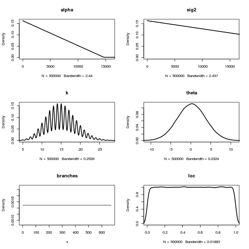

We can simulate some values from the prior distribution to test to make sure our prior function works.

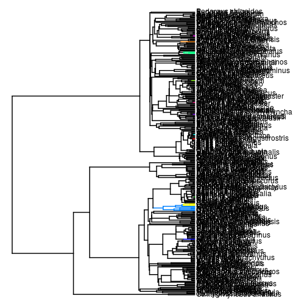

```r
startpars <- priorSim(priorOU, tree, plot=TRUE)$pars[[1]]
```

```r
priorOU(startpars)
```

```
## [1] -104.5195
```

Now that we have a prior function, let’s build an MCMC object that will help us run our analyses.

```r
set.seed(1)
mcmcOU <- bayou.makeMCMC(tree, dat, SE=ME, prior=priorOU, new.dir="../output/runs/modelOU/", outname="modelOU_r001", plot.freq=NULL)
```

To run the analysis, use the ‘run’ function in the mcmcOU object and specify the number of generations. If this amount of generations is insufficient, the MCMC chain will restart from its previous point (as long as the output files have not been removed.)

```r
mcmcOU$run(10000)
```

```
## gen     lnL     prior   alpha   sig2    rtheta  k       .alpha  birth.k D0.slid D1.slid death.k .sig2   .theta  U0.slid U1.slid U2.slid
## 1000    -687.70 -136.36 0.99    7.79    0.37    18      0.27    0.03    1.00    0.36    0.77    0.23    0.76    1.00    0.57    0.46
## 2000    -603.67 -137.66 1.42    6.35    -0.49   18      0.26    0.02    0.98    0.37    0.76    1.00    0.20    0.73    1.00    0.45    0.40
## 3000    -556.95 -154.74 3.25    10.20   0.96    21      0.24    0.02    0.99    0.39    0.72    1.00    0.20    0.72    1.00    0.38    0.39
## 4000    -535.82 -161.38 5.26    15.55   0.91    22      0.24    0.02    0.99    0.40    0.63    1.00    0.22    0.70    1.00    0.25    0.24
## 5000    -540.18 -161.39 8.53    23.94   0.63    22      0.25    0.02    0.99    0.39    0.58    0.86    0.22    0.67    1.00    0.21    0.22
## 6000    -536.50 -149.33 5.14    13.41   0.42    20      0.24    0.02    0.99    0.43    0.58    0.89    0.22    0.66    1.00    0.18    0.23
## 7000    -531.11 -124.80 3.87    10.91   -0.07   16      0.25    0.02    0.99    0.41    0.57    0.90    0.22    0.64    1.00    0.16    0.24
## 8000    -507.24 -156.12 4.53    10.09   -0.07   21      0.24    0.02    0.99    0.40    0.52    0.90    0.23    0.63    1.00    0.13    0.21
## 9000    -530.83 -143.90 3.74    10.11   -0.21   19      0.24    0.01    0.99    0.38    0.51    0.90    0.24    0.62    1.00    0.13    0.20
## 10000   -533.58 -119.32 4.10    11.37   -0.15   15      0.25    0.01    0.99    0.39    0.51    0.90    0.24    0.61    0.99    0.12    0.18
```

Load the chain back into R and clean up the output files, saving the chain as an RDS file.

```r
chainOU <- mcmcOU$load(saveRDS=TRUE, cleanup=TRUE)
```

```
## file saved to ../output/runs/modelOU///modelOU_r001.chain.rds
```

Set the burnin proportion for plotting with coda to check the MCMC chains

```r
chainOU <- set.burnin(chainOU, 0.3)
summary(chainOU)
```

```
## bayou MCMC chain: 10000 generations
## 1001 samples, first 300 samples discarded as burnin
```

```
##
##
## Summary statistics for parameters:
##                    Mean         SD   Naive SE Time-series SE
## lnL        -532.9472845 11.4312747 0.43144566      6.2537627
## prior      -146.3337814 12.0564989 0.45504323      5.0758750
## alpha         4.9054029  1.3451111 0.05076795      0.4146434
## sig2         13.6115914  3.8928516 0.14692622      1.5234124
## k            19.4829060  2.0224471 0.07633235      0.8667291
## ntheta       20.4829060  2.0224471 0.07633235      0.8667291
## root.theta    0.1058022  0.4114046 0.01552747      0.1665544
## all theta     1.0208560  2.3732706         NA             NA
##            Effective Size   HPD95Lower   HPD95Upper
## lnL              3.341231 -560.3608396 -513.6343952
## prior            5.641838 -167.7538156 -125.0146441
## alpha           10.523659    3.1939646    7.8009950
## sig2             6.529813    7.9557234   21.0611904
## k                5.444871   16.0000000   23.0000000
## ntheta           5.444871   17.0000000   24.0000000
## root.theta       6.101351   -0.2202896    0.9135595
## all theta              NA    1.0208560    2.3732706
##
##
## Branches with posterior probabilities higher than 0.1:
##            pp magnitude.of.theta2 naive.SE.of.theta2 rel.location
## 218 1.0000000         -3.35687695        0.005393977 1.194911e-01
## 275 1.0000000         -1.57514890        0.007297555 4.310465e-03
## 637 1.0000000          3.91884164        0.009529892 9.749762e-01
## 642 0.9572650          1.83449905        0.025993365 2.780579e-01
## 638 0.9415954          3.89182623        0.043637736 1.518956e+00
## 660 0.9387464          4.90922610        0.022240260 1.115118e+00
## 565 0.8390313          4.75509737        0.028141367 2.671815e-02
## 388 0.7991453          2.36130213        0.016090889 4.144798e-01
## 100 0.7179487          0.75084446        0.017275773 1.785986e+01
## 99  0.6837607          1.97300736        0.028091569 1.300493e+00
## 588 0.5641026         -2.65031946        0.060715710 5.057097e-01
## 448 0.5384615          1.79410113        0.015700013 8.539806e-01
## 440 0.4928775         -0.99606557        0.016202051 2.207369e-01
## 509 0.3660969          3.43172656        0.016707489 1.116112e+00
## 452 0.3532764          0.42737528        0.029308828 1.873375e-01
```

[output cut: 18 more lines]

```
## 228 0.1794872         -1.23125774        0.039849858 3.886375e-01
## 374 0.1723647          2.57527929        0.026815870 4.379334e+00
## 109 0.1652422         -0.62373014        0.038717518 3.187044e+00
## 357 0.1652422          1.53333498        0.072176163 1.160012e+02
## 527 0.1566952          3.12064343        0.030333113 8.062767e+01
## 664 0.1495726          0.05762406        0.021644498 6.723867e+00
## 450 0.1452991          0.76047884        0.052459032 1.532642e-01
## 459 0.1381766         -0.54439921        0.029465367 7.011424e+00
## 462 0.1210826         -0.84497023        0.025768953 5.243179e-02
## 333 0.1153846          0.16593947        0.064784600 4.765326e-01
## 528 0.1153846          0.91539018        0.036051437 2.114233e-01
## 661 0.1082621          2.69090638        0.094111631 2.437446e-01
## 454 0.1068376          0.05841841        0.051906823 2.088461e-01
## 205 0.1039886         -3.22133169        0.039111039 7.061690e-02
## 449 0.1025641          0.64069831        0.038535005 3.214141e-01
```

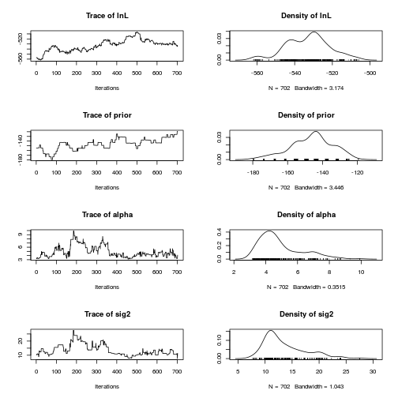

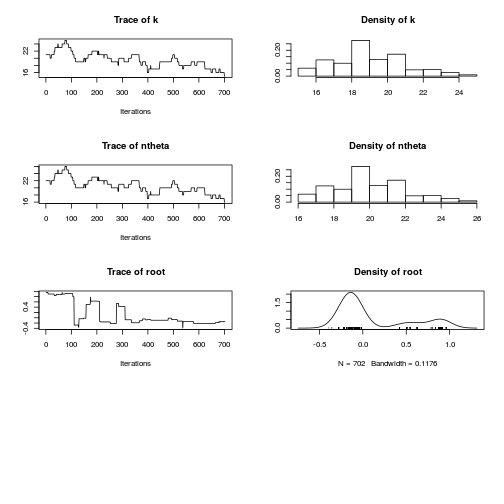

```r
plot(chainOU)
```

## Visualization

Visualizing a tree this large is difficult on a screen as small as ours, so let’s output the file to a pdf with larger dimensions, so that we can read the tip labels.

```r
pdf("../output/runs/modelOU/ModelOUHeatMap.pdf", height=20, width=8)
```

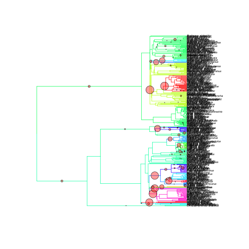

```r
#Posterior probabilities proportional to circle diameter:
plotSimmap.mcmc(chainOU, burnin=0.3, cex=0.5)
```

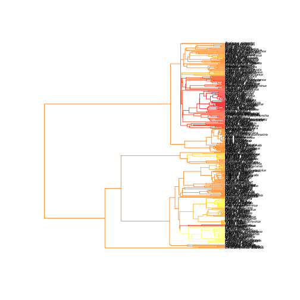

```r
#Branch color proportional to posterior mode value for theta
plotBranchHeatMap(tree, chainOU, variable="theta", burnin=0.3, cex=0.5, lwd=2)
```

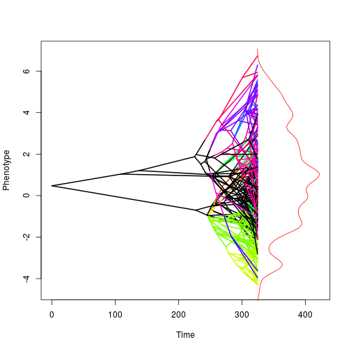

```r
#Phenogram with branches with posterior probabilities > 0.3 colored and a density plot of the posterior of all thetas:
phenogram.density(tree, dat, burnin=0.3, chainOU, pp.cutoff=0.3)
```

```r
dev.off()
```

```r
pdf("../output/runs/modelOU/ShiftSummaries.pdf", height=8, width=8)
```

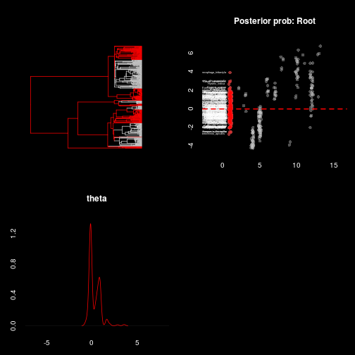

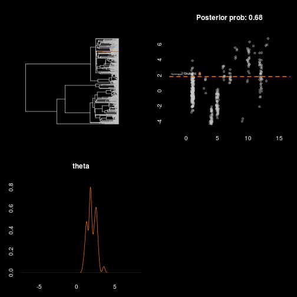

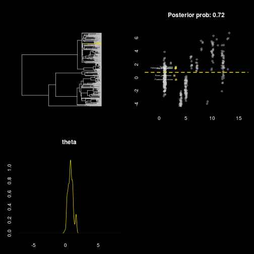

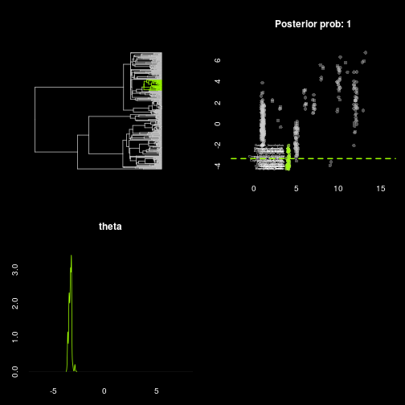

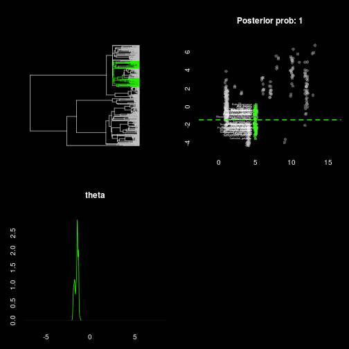

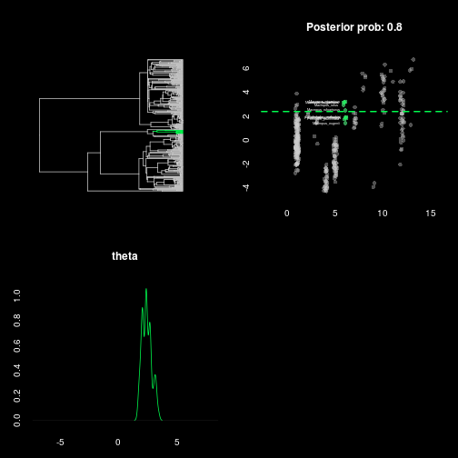

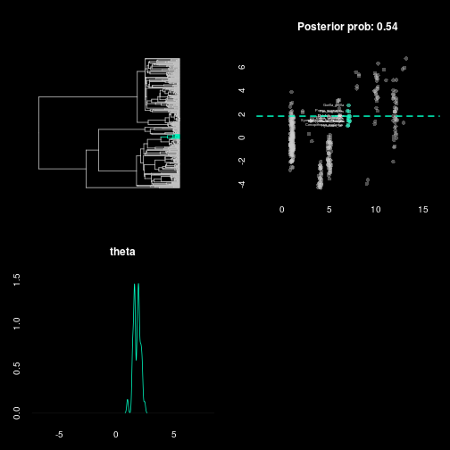

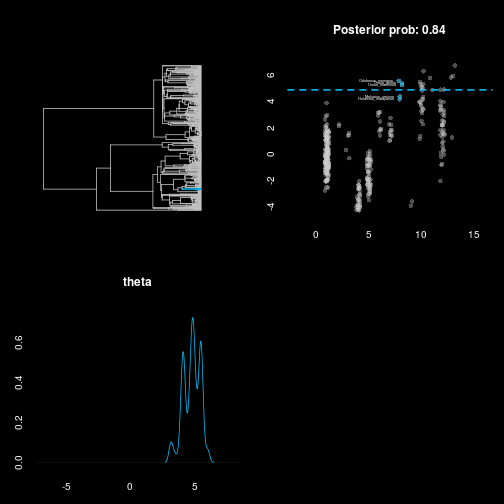

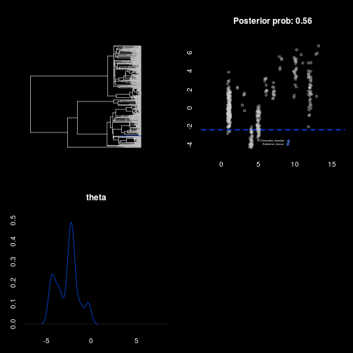

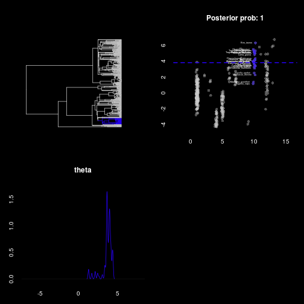

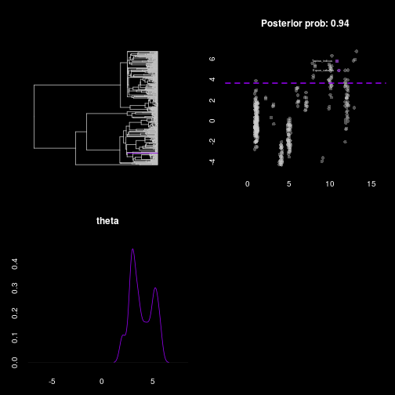

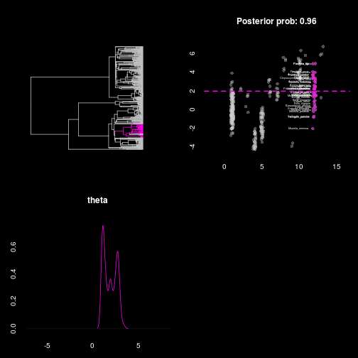

[1 more figures not shown]

```r
shiftsumOU <- shiftSummaries(chainOU, mcmcOU, pp.cutoff=0.5)
plotShiftSummaries(shiftsumOU)
```

```r
dev.off()
```

Or you can plot samples from the posterior distribution:

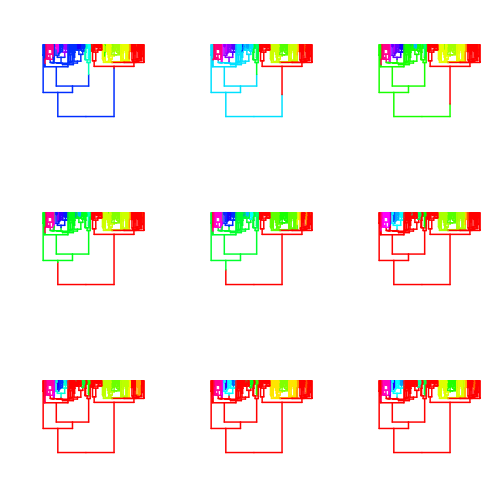

```r
par(mfrow=c(3,3))
for(i in seq(floor(0.3*length(chainOU$gen)), length(chainOU$gen), length.out=9)){
  samplepars <- pull.pars(i, chainOU, model=mcmcOU$model.pars)
  tr <- pars2simmap(samplepars, tree)
  plotRegimes(tr$tree, pal=rainbow, lwd=2, type="phylogram", direction="upwards", show.tip.label=FALSE)
}
```

```r
par(mfrow=c(1,1))
```

# Alternative parameterizations

Two alternative parameterizations of the OU model are built into bayou. First, is a parameterization where priors can be placed directly on phylogenetic half-life and stationary variance, rather than alpha and sigma^2. For example, let’s say we want to have a mildly informative prior on the phylogenetic half-life–say a log-normal distribution:

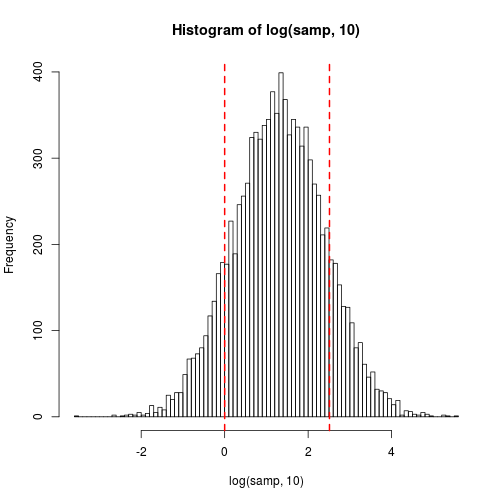

```r
par.halflife <- list(meanlog=3, sdlog=2.5)
#Draw a bunch of samples from this distribution:
samp <- rlnorm(10000, par.halflife$meanlog, par.halflife$sdlog)
hist(log(samp,10), breaks=100)
abline(v=log(c(1,max(branching.times(tree))),10), col="red", lwd=2, lty=2)
```

Notice that there is about equal density of prior probability on the half-life being greater than tree height (rightmost red line) as there is below 1 million years (leftmost red line). The exact quantiles of this distribution are:

```r
qlnorm(c(0.025, 0.25, 0.5, 0.75, 0.975), meanlog=par.halflife$meanlog, sdlog=par.halflife$sdlog)
```

```
## [1]    0.1495821    3.7201933   20.0855369  108.4429660 2697.0394795
```

Second, we’ll set the prior on the stationary variance of the OU process from the Blunderbuss model, as this seems to be the “niche width” we expect to see on million year timescales. We will center it at the estimate from the multiple-burst model from Uyeda et al. 2011:

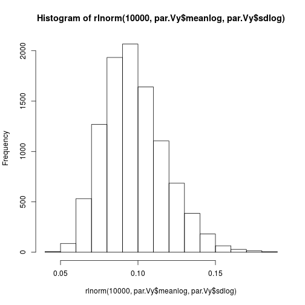

```r
par.Vy <- list(meanlog=log(0.0958), sdlog=0.2)
hist(rlnorm(10000, par.Vy$meanlog, par.Vy$sdlog))
```

```r
priorBB <- make.prior(tree,
                     dists=list(dhalflife="dlnorm", dVy="dlnorm",
                                dk="cdpois", dsb="dsb", dtheta="dnorm"),
                     param=list(dhalflife=par.halflife,
                                dVy=par.Vy,
                                dk=list(lambda=15, kmax=200), dsb=list(bmax=1, prob=1),
                                dtheta=list(mean=mean(dat), sd=1.5*sd(dat))),
                     model="OUrepar"
)
```

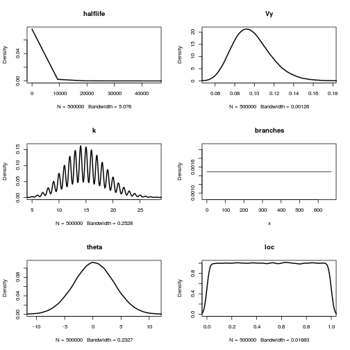

We then run everything as we did before.

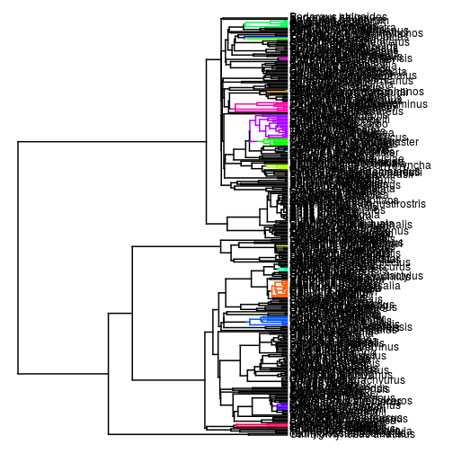

```r
startparsBB <- priorSim(priorBB, tree, plot=TRUE)$pars[[1]]
```

```r
priorBB(startparsBB)
```

```
## [1] -135.101
```

Now that we have a prior function, let’s build an MCMC object that will help us run our analyses.

```r
set.seed(1)
mcmcBB <- bayou.makeMCMC(tree, dat, SE=ME, model="OUrepar", prior=priorBB, new.dir="../output/runs/modelBB/", outname="modelBB_r001", plot.freq=NULL)
mcmcBB$run(10000)
```

```
## gen     lnL     prior   halflif Vy      rtheta  k       birth.k D0.slid D1.slid death.k .halfli .theta  U0.slid U1.slid U2.slid .Vy
## 1000    -552.46 -196.92 34.19   1.59    0.78    12      0.03    0.88    0.36    1.00    0.25    0.80    0.85    0.78    0.43    0.28
## 2000    -527.09 -227.96 27.96   1.60    0.05    17      0.03    0.94    0.48    0.82    0.27    1.00    0.82    0.84    0.42    0.37    0.23
## 3000    -510.08 -211.43 20.78   1.27    -0.41   17      0.02    0.90    0.41    0.78    0.28    1.00    0.78    0.84    0.26    0.28    0.22
## 4000    -507.19 -203.68 12.77   0.91    -0.50   19      0.02    0.92    0.40    0.70    0.28    1.00    0.76    0.88    0.19    0.23    0.21
## 5000    -494.57 -189.08 17.43   1.06    -0.15   15      0.02    0.92    0.42    0.62    0.29    1.00    0.73    0.89    0.15    0.20    0.20
## 6000    -499.78 -181.95 17.66   0.94    -0.26   15      0.02    0.93    0.39    0.55    0.29    1.00    0.72    0.88    0.13    0.18    0.20
## 7000    -502.71 -190.28 22.74   0.94    -0.21   16      0.01    0.93    0.36    0.51    0.29    1.00    0.72    0.88    0.11    0.16    0.21
## 8000    -495.50 -181.24 23.45   1.11    -0.31   13      0.01    0.91    0.34    0.49    0.29    1.00    0.72    0.87    0.10    0.13    0.21
## 9000    -490.63 -191.57 18.83   0.99    -0.30   16      0.01    0.92    0.33    0.45    0.29    1.00    0.71    0.88    0.09    0.13    0.21
## 10000   -486.83 -200.10 16.51   0.94    -0.30   18      0.01    0.93    0.35    0.43    0.29    1.00    0.70    0.88    0.10    0.14    0.21
```

```r
chainBB <- mcmcBB$load()
chainBB <- set.burnin(chainBB, 0.3)
summary(chainBB)
```

```
## bayou MCMC chain: 10000 generations
## 1001 samples, first 300 samples discarded as burnin
```

```
##
##
## Summary statistics for parameters:
##                    Mean          SD    Naive SE Time-series SE
## lnL        -494.3768221  7.01558696 0.264786266     2.05431429
## prior      -196.5093913 11.20421122 0.422875702     4.50691783
## halflife     18.3909862  2.63445220 0.099430991     0.52496397
## Vy            1.0425029  0.08856605 0.003342710     0.01984305
## k            16.3048433  1.89630000 0.071571231     0.90350282
## ntheta       17.3048433  1.89630000 0.071571231     0.90350282
## root.theta   -0.2325926  0.14690621 0.005544617     0.05315134
## all theta     0.6960997  3.08945778          NA             NA
##            Effective Size   HPD95Lower    HPD95Upper
## lnL             11.662570 -508.3806252 -482.48060253
## prior            6.180211 -216.9598583 -175.06020835
## halflife        25.183823   14.1019596   23.60165231
## Vy              19.921302    0.8914944    1.21157388
## k                4.405093   13.0000000   20.00000000
## ntheta           4.405093   14.0000000   21.00000000
## root.theta       7.639269   -0.5096434   -0.01490984
## all theta              NA    0.6960997    3.08945778
##
##
## Branches with posterior probabilities higher than 0.1:
##            pp magnitude.of.theta2 naive.SE.of.theta2 rel.location
## 148 1.0000000           1.2578623        0.021472565 4.672740e-02
## 388 1.0000000           2.3636107        0.019430115 8.986194e-01
## 577 1.0000000          -3.8356362        0.070434899 2.182879e-02
## 637 1.0000000           4.1799902        0.009112012 5.934092e-01
## 638 1.0000000           5.1384671        0.026941557 3.304781e+00
## 663 0.9914530           2.2748041        0.041316954 6.370773e+00
## 588 0.9287749          -3.7775447        0.040140905 4.436221e-01
## 218 0.8618234          -3.5659725        0.015984692 6.511662e-02
## 662 0.8504274           0.3945784        0.008711278 5.636071e-01
## 275 0.8376068          -1.7422325        0.006709745 5.927459e-03
## 650 0.7279202           5.8181472        0.032701015 1.445466e-01
## 527 0.6139601           3.6728024        0.042879187 6.835522e+01
## 583 0.3874644           2.9351718        0.031812882 8.244416e-01
## 642 0.3347578           2.3477120        0.011279248 2.017379e-01
## 152 0.2891738          -1.2193568        0.056083477 5.736130e-01
## 581 0.2678063           4.5890854        0.093204885 6.928101e+00
## 565 0.2521368           4.9313463        0.043727067 6.267884e-03
## 287 0.2165242           0.4301308        0.101618805 1.642082e-01
## 86  0.1894587           0.4918631        0.017730165 1.292323e+02
## 573 0.1809117          -4.7694457        0.086403641 8.327390e-02
## 151 0.1766382          -1.2927139        0.060539495 3.635682e-01
## 274 0.1623932          -1.6841224        0.023891397 7.220818e-01
## 236 0.1552707           1.7744845        0.035065414 1.274374e+01
## 102 0.1538462          -1.6785775        0.021598691 1.393930e+00
## 661 0.1438746           2.0757642        0.035714012 5.152011e-01
## 30  0.1424501           1.0209145        0.017912925 8.532257e-01
## 40  0.1125356           1.3091584        0.012423515 6.891511e-01
## 49  0.1125356           1.9151113        0.076490815 1.692192e+00
## 41  0.1011396           1.2665042        0.021228918 2.907092e-01
```

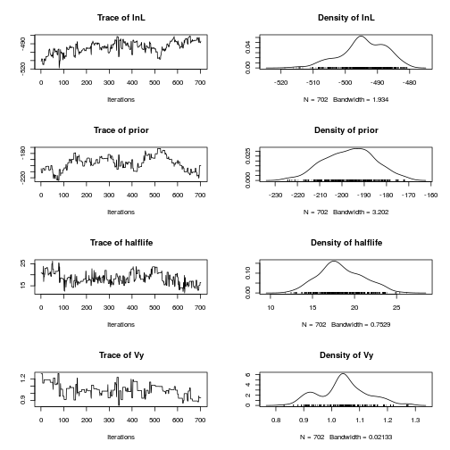

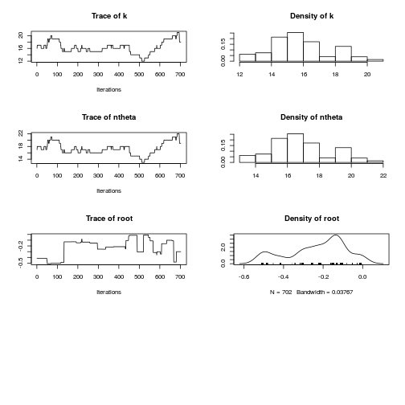

```r
plot(chainBB)
```

```r
pdf("../output/runs/modelBB/ModelBBHeatMap.pdf", height=20, width=8)
```

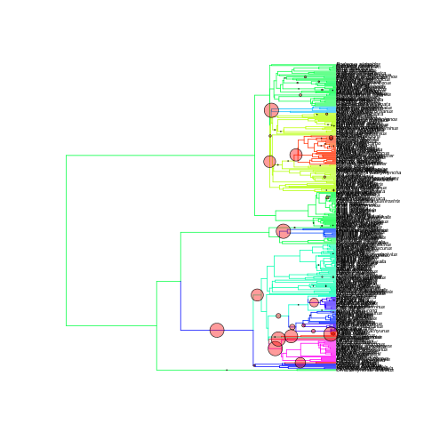

```r
#Posterior probabilities proportional to circle diameter:
plotSimmap.mcmc(chainBB, burnin=0.3, cex=0.5)
```

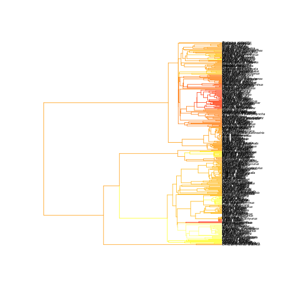

```r
#Branch color proportional to posterior mode value for theta
plotBranchHeatMap(tree, chainBB, variable="theta", burnin=0.3, cex=0.5, lwd=2)
```

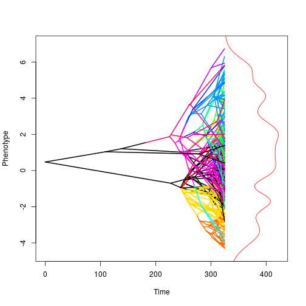

```r
#Phenogram with branches with posterior probabilities > 0.3 colored and a density plot of the posterior of all thetas:
phenogram.density(tree, dat, burnin=0.3, chainBB, pp.cutoff=0.3)
```

```r
dev.off()
```

## Quantitative Genetics Model

We can also fit a model that follows the Quantitative Genetics parameterization. You can check the specified prior distributions on your own, but these are informative priors that specify moderate to high heritability, realistic phenotypic variances, large uncertainty regarding the strength of selection and reasonable effective population sizes for entire species.

```r
par.h2 <- list(shape1=10, shape2=10)
par.P <- list(meanlog=log(0.12), sdlog=0.2)
par.w2 <- list(meanlog=log(100), sdlog=2.5)
par.Ne <- list(meanlog=log(500000), sdlog=2.5)
```

We should rescale the branch lengths to correspond roughly to generation time. However, here we will assume that for most of the history of birds and mammals, the generation time has been around 2 year/gen.

```r
QGtree <- tree
QGtree$edge.length <- QGtree$edge.length/2

priorQG <- make.prior(QGtree,
                      dists=list(dh2="dbeta", dP="dlnorm",
                                 dw2="dlnorm", dNe="dlnorm",
                                 dk="cdpois", dtheta="dnorm"),
                      param=list(dh2=par.h2,
                                 dP=par.P,
                                 dw2=par.w2,
                                 dNe=par.Ne,
                                 dk=list(lambda=30, kmax=200), dsb=list(bmax=1, prob=1),
                                 dtheta=list(mean=mean(dat), sd=1.5*sd(dat))),
                      model="QG"
)
```

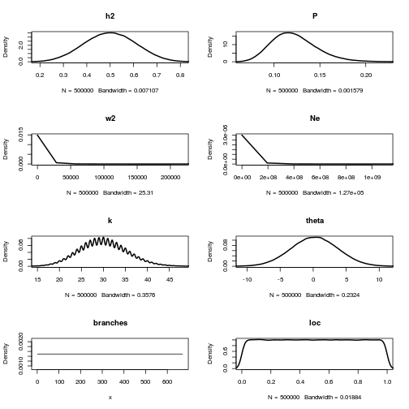

Note that this model has difficulty fitting if the starting point is a poor fit. So rather than drawing from the prior distribution, we will start with shifts chosen by previous analyses:

```r
endparBB <- pull.pars(length(chainBB$gen), chainBB, mcmcBB$model.pars)
startpars <- priorSim(priorQG, QGtree)$pars[[1]]
```

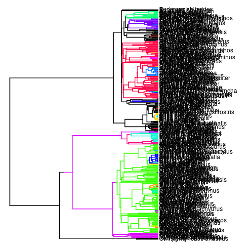

```r
startpars <- c(startpars[1:4], endparBB[3:8])
startpars$loc <- startpars$loc/2

set.seed(100)
mcmcQG <- bayou.makeMCMC(QGtree, dat, SE=ME, model="QG", startpar=startpars, prior=priorQG, new.dir="../output/runs/modelQG/", outname="modelQG_r001", plot.freq=NULL)
mcmcQG$run(10000)
```

```
## gen     lnL     prior   h2      P       w2      Ne      rtheta  k       birth.k D0.slid D1.slid death.k .h2     .Ne     .P      .theta  U0.slid U1.slid U2.slid .w2
## 1000    -532.05 -435.35 0.72    2.90    2087.93 21.61   0.96    45      0.11    1.00    0.88    0.75    0.16    0.49    0.40    0.83    0.76    0.40    0.58    0.77
## 2000    -525.28 -228.33 0.80    0.32    46.03   1.95    1.72    29      0.07    1.00    0.83    0.88    0.20    0.36    0.39    0.90    0.89    0.62    0.47    0.76
## 3000    -528.85 -215.03 0.67    0.17    124.32  1.19    0.45    29      0.06    1.00    0.77    0.90    0.25    0.31    0.32    0.92    0.91    0.67    0.53    0.69
## 4000    -526.38 -158.51 0.47    0.18    22.69   0.68    0.31    19      0.05    0.98    0.77    0.92    0.25    0.30    0.29    0.93    0.92    0.68    0.51    0.67
## 5000    -529.27 -146.09 0.45    0.15    55.44   0.55    -0.53   17      0.04    0.96    0.69    0.92    0.25    0.28    0.29    0.92    0.94    0.65    0.57    0.67
## 6000    -530.46 -135.64 0.33    0.10    121.39  0.29    0.93    15      0.04    0.97    0.70    0.93    0.26    0.27    0.29    0.93    0.95    0.70    0.57    0.68
## 7000    -530.45 -115.62 0.49    0.11    162.18  0.50    0.71    12      0.03    0.98    0.67    0.94    0.25    0.27    0.29    0.93    0.95    0.68    0.56    0.70
## 8000    -531.44 -112.25 0.50    0.11    580.39  0.53    1.07    11      0.03    0.97    0.67    0.94    0.25    0.27    0.27    0.94    0.96    0.70    0.59    0.71
## 9000    -531.62 -109.53 0.54    0.17    289.46  0.87    -0.24   10      0.03    0.98    0.66    0.94    0.24    0.27    0.26    0.94    0.97    0.71    0.63    0.74
## 10000   -530.32 -112.58 0.58    0.15    69.27   0.70    0.69    11      0.03    0.98    0.66    0.95    0.24    0.26    0.25    0.94    0.97    0.72    0.64    0.74
```

```r
chainQG <- mcmcQG$load()
chainQG <- set.burnin(chainQG, 0.3)
summary(chainQG)
```

```
## bayou MCMC chain: 10000 generations
## 1001 samples, first 300 samples discarded as burnin
```

```
##
##
## Summary statistics for parameters:
##                     Mean           SD    Naive SE Time-series SE
## lnL        -529.75850472   2.05482497 0.077554371     1.13650435
## prior      -133.16403861  28.34941540 1.069979733    15.45911566
## h2            0.51049132   0.10314224 0.003892853     0.03400315
## P             0.13456360   0.03067667 0.001157816     0.01743036
## w2          120.25231220 106.73319829 4.028384973    32.91787543
## Ne            0.60173946   0.23075616 0.008709330     0.11687735
## k            14.67094017   4.90639735 0.185180035     2.60911338
## ntheta       15.67094017   4.90639735 0.185180035     2.60911338
## root.theta    0.65075514   0.65107230 0.024573140     0.20012489
## all theta    -0.05767739   2.41563662          NA             NA
##            Effective Size    HPD95Lower   HPD95Upper
## lnL              3.268944 -532.49171959 -524.9582125
## prior            3.362938 -204.62277693 -103.4978430
## h2               9.200996    0.25816671    0.6663179
## P                3.097446    0.09489550    0.1930953
## w2              10.513213   19.04986517  349.1600075
## Ne               3.898037    0.18433312    1.0430682
## k                3.536222   10.00000000   27.0000000
## ntheta           3.536222   11.00000000   28.0000000
## root.theta      10.584156   -0.57879593    1.6783864
## all theta              NA   -0.05767739    2.4156366
##
##
## Branches with posterior probabilities higher than 0.1:
##            pp magnitude.of.theta2 naive.SE.of.theta2 rel.location
## 607 0.9729345         -0.32636738         0.04866786 3.360939e-01
## 83  0.5085470         -2.00216764         0.03417874 2.444759e+00
## 338 0.4943020         -1.23411926         0.02822983 3.431769e-01
## 623 0.4786325          0.80073366         0.03751345 3.605698e+00
## 111 0.3974359          1.87561458         0.04537336 5.764869e-01
## 414 0.3732194          1.37988701         0.06434598 1.214060e+01
## 326 0.3219373          1.86667050         0.08974009 3.332000e+00
## 118 0.3105413         -1.44997424         0.05107195 5.623125e-01
## 636 0.3005698          4.29064042         0.08422988 2.360095e+00
## 541 0.2905983          1.72545490         0.03732998 6.094247e-01
## 581 0.2891738         -0.39667884         0.06386487 5.339380e+00
```

[output cut: 23 more lines]

```
## 52  0.1367521          4.35395985         0.03446469 2.893051e-02
## 182 0.1353276         -0.95742759         0.04646551 1.281267e+00
## 594 0.1253561         -0.12726593         0.05391077 3.719954e-01
## 40  0.1210826          4.80683953         0.05153549 6.119333e-01
## 147 0.1210826         -2.34819173         0.07159510 5.047319e-02
## 156 0.1210826         -2.63719403         0.08954485 2.437168e-01
## 41  0.1139601          4.14736150         0.02304615 6.805598e-01
## 51  0.1139601          0.73750227         0.09928997 3.066102e+00
## 122 0.1139601          2.75939709         0.05735308 2.121317e-01
## 33  0.1125356          3.73034013         0.03780978 4.329692e+16
## 13  0.1096866         -0.88722689         0.03231778 3.580330e-01
## 66  0.1054131         -2.66645867         0.14146004 6.498034e-01
## 49  0.1039886         -0.17222926         0.15582965 1.715168e+00
## 549 0.1025641         -2.11302829         0.04028090 1.462071e+00
## 325 0.1011396         -0.60984410         0.11219692 8.099235e-01
```